# Chi Squared Test

### Hypothesis

Our null and alternative hypothesis are as follows:

$$H_0: \text{Birth month and favorite season are independent.}$$

$$H_0: \text{Birth month and favortie season are associated (not
independent).}$$
We will be using a level of significance α=0.05.

### A look at the Data

Here we can see what the results were from the survey. Students were asked to record their birth month (columns) as well as their favorite season(rows). The count for each combination of responses is shown in the table below.

```r
y <- table(data$Favorite_Season, data$Birth_month)
pander::pander(y)
```

Table continues below

|  | April | August | December | February | January | July | June |
| --- | --- | --- | --- | --- | --- | --- | --- |
| **Fall** | 13 | 17 | 11 | 10 | 14 | 9 | 15 |
| **Spring** | 5 | 11 | 6 | 6 | 7 | 7 | 7 |
| **Summer** | 8 | 12 | 11 | 9 | 11 | 16 | 12 |
| **Winter** | 11 | 5 | 19 | 3 | 9 | 8 | 5 |

|  | March | May | November | October | September |
| --- | --- | --- | --- | --- | --- |
| **Fall** | 10 | 10 | 18 | 12 | 17 |
| **Spring** | 7 | 10 | 6 | 4 | 6 |
| **Summer** | 14 | 8 | 8 | 7 | 8 |
| **Winter** | 10 | 5 | 9 | 8 | 9 |

The data from the table has been placed in the graph below for visualization. It is important to note that the months are not in sequential order. At a glance it may seem like there could be some sort of correlation. For example, December, a Winter month, seems to have a higher winter column.

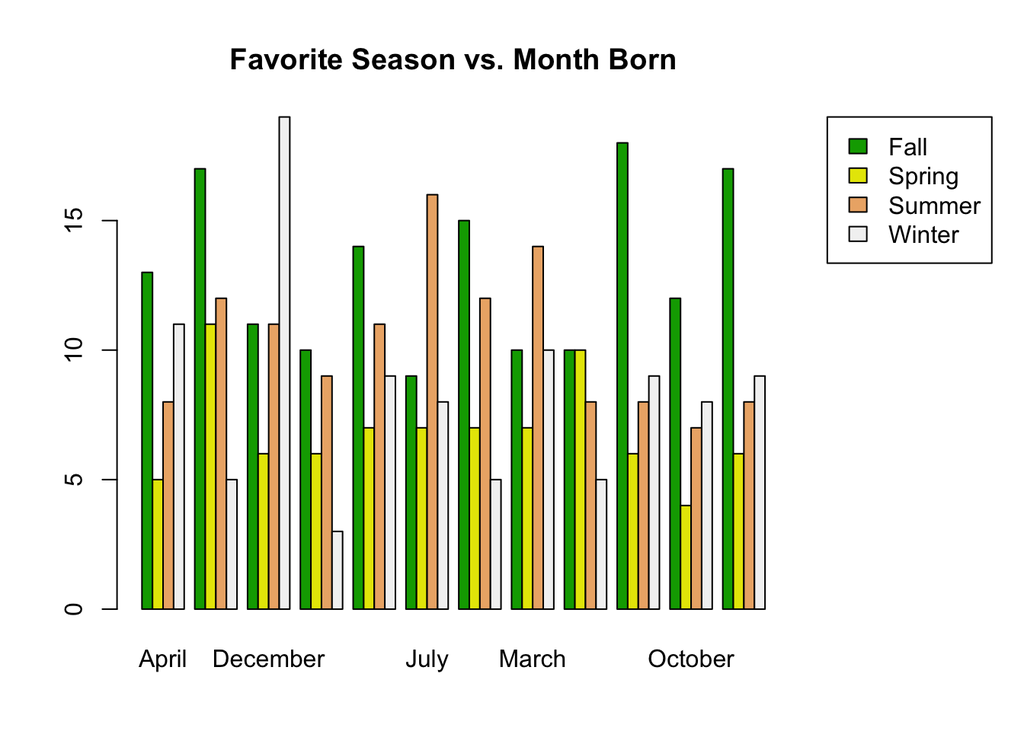

```r
par(mar = c(4,4,4, 8), xpd = T, mfrow = c(1,1))
barplot(y, beside = T, col = terrain.colors(4),
        main = "Favorite Season vs. Month Born")
legend("topright", inset = c(-.3,0), legend = c("Fall","Spring","Summer","Winter"), fill=terrain.colors(4))
```

### Test

Running a chi-squared test using R will tell us if any trends we may seem to notice are actually significant. Put more clearly, our test will tell us if we will reject the null hypothesis or not that birth month does not affect people’s preference of season.

```r
y <- table(data$Favorite_Season, data$Birth_month)

chis.kids <- chisq.test(y)
chis.kids %>% pander::pander()
```

Pearson’s Chi-squared test: `y`

| Test statistic | df | P value |
| --- | --- | --- |
| 34.58 | 33 | 0.3924 |

We see that we come up with a p-value of .3924, which is much more than our level of significance .05, so we fail to reject the null hypothesis.

### Checking Test Validity

Even though we fail to reject the null in this case, it is still important to check the requirements of our test.

```r
pander::pander(chis.kids$expected)
```

Table continues below

|  | April | August | December | February | January | July | June |
| --- | --- | --- | --- | --- | --- | --- | --- |
| **Fall** | 12.47 | 15.16 | 15.84 | 9.434 | 13.81 | 13.48 | 13.14 |
| **Spring** | 6.553 | 7.97 | 8.324 | 4.959 | 7.261 | 7.084 | 6.907 |
| **Summer** | 9.909 | 12.05 | 12.59 | 7.499 | 10.98 | 10.71 | 10.44 |
| **Winter** | 8.071 | 9.816 | 10.25 | 6.108 | 8.944 | 8.726 | 8.508 |

|  | March | May | November | October | September |
| --- | --- | --- | --- | --- | --- |
| **Fall** | 13.81 | 11.12 | 13.81 | 10.44 | 13.48 |
| **Spring** | 7.261 | 5.844 | 7.261 | 5.49 | 7.084 |
| **Summer** | 10.98 | 8.838 | 10.98 | 8.302 | 10.71 |
| **Winter** | 8.944 | 7.199 | 8.944 | 6.762 | 8.726 |

Typically, all expected counts are required to be 5 or greater for the test to be appropriate. However, the test is still appropriate if all expected counts are at least 1 and the average of the expected counts is at least 5. In this case one of our expected counts is barely below 5, but we can know that all are above 1 and that the average of them all is well above 5. We can say that our requirements are met.

```r
pander::pander(chis.kids$residuals)
```

Table continues below

|  | April | August | December | February | January | July |
| --- | --- | --- | --- | --- | --- | --- |
| **Fall** | 0.1511 | 0.472 | -1.215 | 0.1842 | 0.04998 | -1.22 |
| **Spring** | -0.6066 | 1.073 | -0.8055 | 0.4675 | -0.09698 | -0.03165 |
| **Summer** | -0.6065 | -0.01493 | -0.4474 | 0.5482 | 0.005866 | 1.615 |
| **Winter** | 1.031 | -1.537 | 2.732 | -1.258 | 0.01878 | -0.2457 |

|  | June | March | May | November | October | September |
| --- | --- | --- | --- | --- | --- | --- |
| **Fall** | 0.513 | -1.026 | -0.3355 | 1.126 | 0.4812 | 0.9596 |
| **Spring** | 0.03534 | -0.09698 | 1.719 | -0.4681 | -0.636 | -0.4074 |
| **Summer** | 0.4812 | 0.9112 | -0.2819 | -0.8995 | -0.452 | -0.8288 |
| **Winter** | -1.203 | 0.3532 | -0.8195 | 0.01878 | 0.4759 | 0.09286 |

In this case December/Winter had a much higher residual than the rest, but the rest seem to be very minimal, so it becomes apparent why we did not have a significant p-value.

### Conclusion

In summary, we find that there is no significant effect that birth month has on favorite season. Relating this back to our original question, there is no true merit to this test proving or disproving the affect one’s zodiac sign actually has on personality, however it could be cause for questioning. It The true question lies in how we can accurately classify different personalities. Once this is answered, then run a chi-squared test to see if there really is an association between one’s classified zodiac sign and personality type.